# STA380 II

## Parameter Selection 1:

To begin, we selected a relatively high support confidence ratio and a low confidence level to see what outputs would occur.

6 rules created given the high support confidence ratio and extremely low confidence level.

```
##     lhs                   rhs                support    confidence coverage
## [1] {yogurt}           => {whole milk}       0.05602440 0.4016035  0.1395018
## [2] {whole milk}       => {yogurt}           0.05602440 0.2192598  0.2555160
## [3] {rolls/buns}       => {whole milk}       0.05663447 0.3079049  0.1839349
## [4] {whole milk}       => {rolls/buns}       0.05663447 0.2216474  0.2555160
## [5] {other vegetables} => {whole milk}       0.07483477 0.3867578  0.1934926
## [6] {whole milk}       => {other vegetables} 0.07483477 0.2928770  0.2555160
##     lift     count
## [1] 1.571735 551
## [2] 1.571735 551
## [3] 1.205032 557
## [4] 1.205032 557
## [5] 1.513634 736
## [6] 1.513634 736
```

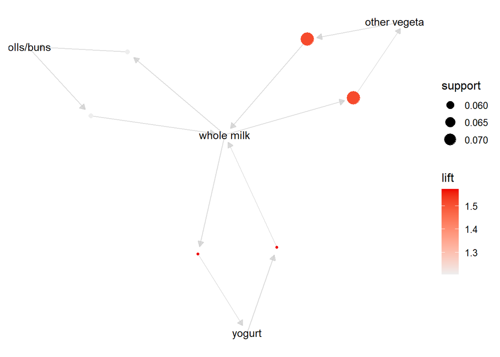

All relationships have whole milk; yogurt, other vegetables, and rolls/buns come up twice. This makes sense given they are all among the most frequently purchased items, as previously shown.

## Parameter Selection 2:

We decreased support confidence ratio and increased confidence levels to see this impact on the output obtained.

128 rules created given the lowered support confidence ratio and slightly higher confidence level.

```
##       lhs                                   rhs                     support
## [1]   {frozen vegetables}                => {whole milk}            0.02043721
## [2]   {whole milk}                       => {frozen vegetables}     0.02043721
## [3]   {beef}                             => {whole milk}            0.02125064
## [4]   {whole milk}                       => {beef}                  0.02125064
## [5]   {curd}                             => {whole milk}            0.02613116
## [6]   {whole milk}                       => {curd}                  0.02613116
## [7]   {pork}                             => {other vegetables}      0.02165735
## [8]   {other vegetables}                 => {pork}                  0.02165735
## [9]   {pork}                             => {whole milk}            0.02216573
## [10]  {whole milk}                       => {pork}                  0.02216573
## [11]  {frankfurter}                      => {whole milk}            0.02053889
## [12]  {whole milk}                       => {frankfurter}           0.02053889
## [13]  {bottled beer}                     => {whole milk}            0.02043721
## [14]  {whole milk}                       => {bottled beer}          0.02043721
```

[output cut: 243 more lines]

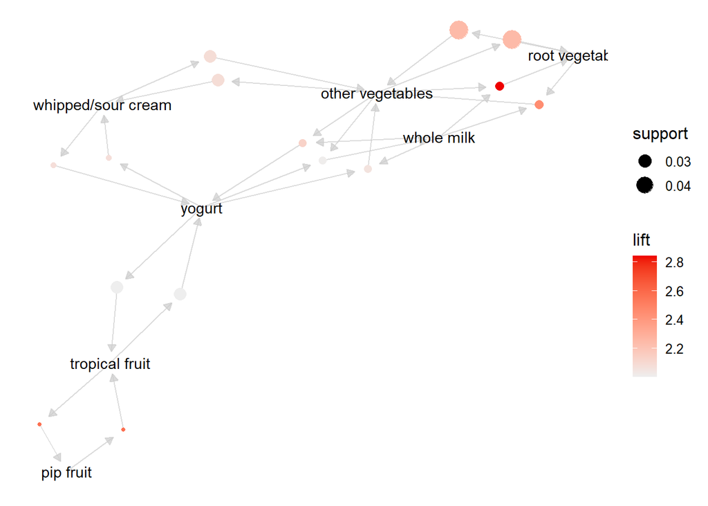

More items are included in this output as a result, but whole milk, yogurt, and other vegetables are still highly present, as shown in this plot.

## Parameter Selection 3:

We further decreased support confidence ratio and further increased confidence levels to see the magnified impact of these parameters on a larger scale.

5111 rules created given the even lower support confidence ratio and significantly higher confidence level.

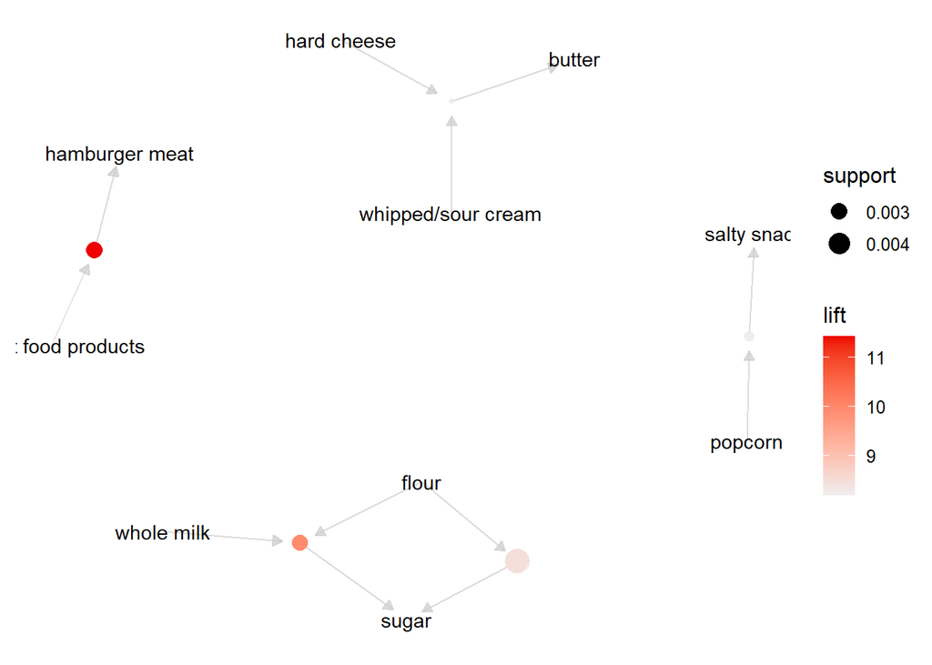

This graph shows that transactions that include whole milk are likely to include other baking supplies. Also shows transactions containing a dairy product like hard cheese will likley include other dairy products. Depicted is also a relationship between transactions containing salty snacks and popcorn, as well as hamburger meat with instant meals. These relationships all make sense given the similarities of the items and their respective food categories.